# Text and Sentiment Analysis: Donald Trump Tweets

Sarah Febres-Cordero

2/13/2019

# Project Milestone 1 - Proposal

Your project proposal, Milestone 1, is due on Wednesday, 13 Februray 2018, by 5:00 pm EST.You will submit a PDF file. This document will contain two links; 1. a link to the Rmd file that created it in your GitHub repo, and 2. a link to the source of your original data. Please put your name on the first page of the document. The document will include the following information: ## 1. a link to the Rmd file that created it in your GitHub repo https://github.com/sarah-febres-cordero/BIG_DATA_PRJECT.git

## 2. a link to the source of your original data.

http/::twitter.com

## Overview and Motivation:

Why did you undertake this particular project? For the current project I am interested in learning the methods to datamine Twitter. ## What inspired you, what are your background and research interests that may have influenced your decision? My inspiration for this project came from my classmate Daniel, I wanted to learn the methods but was having a hard time with the topic. He suggested investigating Trump tweets so that we would be entertained along with learning how to data mine Twitter.

## Project Objectives: What is the primary focal question that you are trying to answer? What would you like to learn and accomplish?

So as I looked into data mining Trump tweets I found an interesting article about how it is hypothesized that Trump tweets from his android phone are written by Trump and those from his IPhone are written by staffers. I would like to see if I can repoduce this data and see if all of the current code works (in the comments it was noted that there were problems with some of the code) and I would like to add to this project by adding some word clouds and analyzing which set of tweets get more public engagement. There is currently a course on DataCamp to learn the methods used to do this project. I would like to follow the cours instructions to see if I can reproduce this work and add to it in some way. https://projects.datacamp.com/projects/511

## Data Wrangling:

Do you anticipate that there will be extensive data cleaning / reshaping / extraction? Are there questions you will need to calculate in your data (e.g., perhaps you have height and weight, but not BMI)? How will you implement this particular data wrangling step? For the project I would utilize data camp by engaging in the project using tidyverse, ggplot2, string manipulation with R with stringr, and sentiment analysis in R: The tidy way

## Exploratory Analysis:

Which methods / visualizations are you planning to use to explore your tidy dataset? I am definetly interested in word clouds, I feel they are especially popular as a teaching tool in nursing classes. If I could learn the methods to generate data in this way I feel it will be useful later as an instructor. *I was curious to see how code would be used to form a cloud. I went online and found some code that I tried in R to see if I could generate a word cloud.

```r
library("tm")
```

```r
library("SnowballC")
library("wordcloud")
library("RColorBrewer")

#####This code is from: http://www.sthda.com/english/wiki/text-mining-and-word-cloud-fundamentals-in-r-5-simple-steps-you-should-know


# Read the text file from internet
filePath <- "http://www.sthda.com/sthda/RDoc/example-files/martin-luther-king-i-have-a-dream-speech.txt"
text <- readLines(filePath)
# Load the data as a corpus
docs <- Corpus(VectorSource(text))
inspect(docs)
```

```
## <<SimpleCorpus>>
## Metadata:  corpus specific: 1, document level (indexed): 0
## Content:  documents: 46
##
##  [1]
##  [2] And so even though we face the difficulties of today and tomorrow, I still have a dream. It is a dream deeply rooted in the American dream.
##  [3]
##  [4] I have a dream that one day this nation will rise up and live out the true meaning of its creed:
##  [5]
##  [6] We hold these truths to be self-evident, that all men are created equal.
##  [7]
##  [8] I have a dream that one day on the red hills of Georgia, the sons of former slaves and the sons of former slave owners will be able to sit down together at the table of brotherhood.
##  [9]
## [10] I have a dream that one day even the state of Mississippi, a state sweltering with the heat of injustice, sweltering with the heat of oppression, will be transformed into an oasis of freedom and justice.
## [11]
## [12] I have a dream that my four little children will one day live in a nation where they will not be judged by the color of their skin but by the content of their character.
## [13]
## [14] I have a dream today!
## [15]
## [16] I have a dream that one day, down in Alabama, with its vicious racists, with its governor having his lips dripping with the words of interposition and nullification, one day right there in Alabama little black boys and black girls will be able to join hands with little white boys and white g…
## [17]
## [18] I have a dream today!
## [19]
## [20] I have a dream that one day every valley shall be exalted, and every hill and mountain shall be made low, the rough places will be made plain, and the crooked places will be made straight; and the glory of the Lord shall be revealed and all flesh shall see it together.
## [21]
## [22] This is our hope, and this is the faith that I go back to the South with.
## [23]
## [24] With this faith, we will be able to hew out of the mountain of despair a stone of hope. With this faith, we will be able to transform the jangling discords of our nation into a beautiful symphony of brotherhood. With this faith, we will be able to work together, to pray together, to struggle…
## [25]
## [26] And this will be the day, this will be the day when all of God s children will be able to sing with new meaning:
## [27]
## [28] My country  tis of thee, sweet land of liberty, of thee I sing.
## [29] Land where my fathers died, land of the Pilgrim s pride,
## [30] From every mountainside, let freedom ring!
## [31] And if America is to be a great nation, this must become true.
## [32] And so let freedom ring from the prodigious hilltops of New Hampshire.
## [33] Let freedom ring from the mighty mountains of New York.
## [34] Let freedom ring from the heightening Alleghenies of Pennsylvania.
## [35] Let freedom ring from the snow-capped Rockies of Colorado.
## [36] Let freedom ring from the curvaceous slopes of California.
## [37]
## [38] But not only that:
## [39] Let freedom ring from Stone Mountain of Georgia.
## [40] Let freedom ring from Lookout Mountain of Tennessee.
## [41] Let freedom ring from every hill and molehill of Mississippi.
## [42] From every mountainside, let freedom ring.
## [43] And when this happens, when we allow freedom ring, when we let it ring from every village and every hamlet, from every state and every city, we will be able to speed up that day when all of God s children, black men and white men, Jews and Gentiles, Protestants and Catholics, will be able to…
## [44] Free at last! Free at last!
## [45]
## [46] Thank God Almighty, we are free at last!
```

```r
toSpace <- content_transformer(function (x , pattern ) gsub(pattern, " ", x))
docs <- tm_map(docs, toSpace, "/")
docs <- tm_map(docs, toSpace, "@")
docs <- tm_map(docs, toSpace, "\\|")
# Convert the text to lower case
docs <- tm_map(docs, content_transformer(tolower))
# Remove numbers
docs <- tm_map(docs, removeNumbers)
# Remove english common stopwords
docs <- tm_map(docs, removeWords, stopwords("english"))
# Remove your own stop word
# specify your stopwords as a character vector
docs <- tm_map(docs, removeWords, c("blabla1", "blabla2"))
# Remove punctuations
docs <- tm_map(docs, removePunctuation)
# Eliminate extra white spaces
docs <- tm_map(docs, stripWhitespace)
# Text stemming
# docs <- tm_map(docs, stemDocument)
#build a matrix
dtm <- TermDocumentMatrix(docs)
m <- as.matrix(dtm)
v <- sort(rowSums(m),decreasing=TRUE)
d <- data.frame(word = names(v),freq=v)
head(d, 10)
```

```
##              word freq
## will         will   17
## freedom   freedom   13
## ring         ring   12
## dream       dream   11
## day           day   11
## let           let   11
## every       every    9
## one           one    8
## able         able    8
## together together    7
```

[figure not shown]

```r
#generate word cloud
set.seed(1234)
wordcloud(words = d$word, freq = d$freq, min.freq = 1,
          max.words=200, random.order=FALSE, rot.per=0.35,
          colors=brewer.pal(8, "Dark2"))
```

```r
#frequent terms and associations
findFreqTerms(dtm, lowfreq = 4)
```

```
##  [1] "dream"    "day"      "nation"   "one"      "will"     "able"
##  [7] "together" "freedom"  "every"    "mountain" "shall"    "faith"
## [13] "free"     "let"      "ring"
```

```r
#associations of terms
findAssocs(dtm, terms = "freedom", corlimit = 0.3)
```

```
## $freedom
##          let         ring  mississippi        stone mountainside
##         0.89         0.86         0.34         0.34         0.34
##        state        every     mountain
##         0.32         0.32         0.32
```

```r
#table
head(d, 10)
```

```
##              word freq
## will         will   17
## freedom   freedom   13
## ring         ring   12
## dream       dream   11
## day           day   11
## let           let   11
## every       every    9
## one           one    8
## able         able    8
## together together    7
```

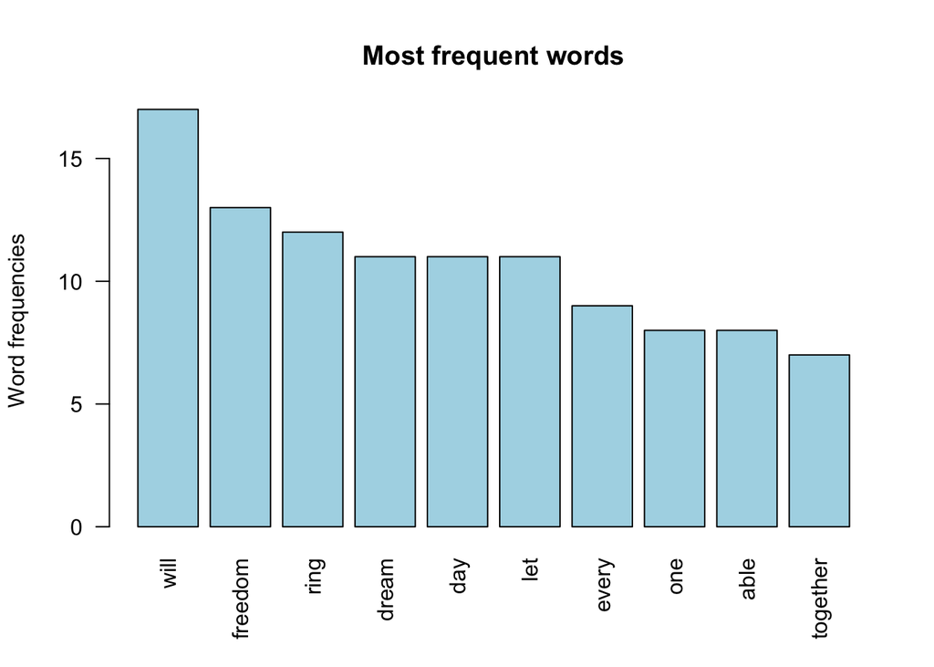

```r
#plot word frequencies
barplot(d[1:10,]$freq, las = 2, names.arg = d[1:10,]$word,
        col ="lightblue", main ="Most frequent words",
        ylab = "Word frequencies")
```

## Analysis:

How are you planning to analyze your data? _ Schedule, keeping in mind the due dates listed above for the intermediate and final milestones, make a plan to meet these deadlines. Write these in terms of weekly tasks / goals. The first task will be to get a developer account with Twitter, I have already been accepted and have started the process. I have read Dr. Higgind Blog posts to try and get as much of this account set up done by Feb. 13. I am having some troubles but plan to investigate this more this week. These are the steps outlined in Dr. Higgins’ blog (http://melindahiggins2000.github.io/web2/blog/r%20codes/2014/12/08/GetDataFromTwitter.html)

- set-up a developer account with Twitter;create a Twitter application to generate a key and token for your API;
- write R code to use this API to pull tweets from Twitter on a given key word or words;
- parse the tweets; and
- then create a word cloud to illustrate a data mining visualization graphic.
- I would like to have this step done by Feb 20
- I would like to have the reproduction of the DataCamp done by the end of February and the additional analysis done by March 20

## As a ballpark, your proposal should be about 2-3 pages of text, along with shells of the tables and figures that you plan. You could even include some preliminary data acquisition / analysis steps.

I have no preliminary data as I have not been able to complete my account set up as of yet.